# Lionsunking_linear_regression_analysis

[figure not shown]

## **Business Context**

In the dynamic and competitive market of mobiles and tablets, retailers need to be aware of market trends and adapt to changing consumer preferences and technological advancements. They also need to efficiently manage inventory and marketing strategies to attract new customers and retain existing ones, ensuring sustained growth and profitability.

A renowned online retailer faces the challenge of managing inventory and managing marketing expenditures. To address these challenges, the retailer aims to accurately forecast sales to make informed decisions regarding inventory management and resource allocation. In addition, they also want to identify key levers influencing sales to strategically focus on areas that can drive growth. The end goal is to minimize stockouts and overstock situations and enhance sales performance to gain a competitive advantage.

## **Objectives**

As a data scientist, you are provided with sales data from the recent past along with other attributes like pricing strategies, promotional activities, and customer engagement. You are required to analyze the data, identify patterns, build a linear regression model to forecast sales, and identify factors contributing to changes in sales.

## **Data Dictionary**

1. Advertising Expenditure: Amount spent on advertisements (in dollars) across different marketing channels
2. Campaign Engagement Score: A score computed by the marketing team based on the engagement (likes, comments, shares) on social media campaigns
3. Discount Percentage: Average discount offered for a given product
4. Average Customer Rating: Average rating provided by customers for the product
5. Product Price: The price of the product (in dollars)
6. Return Rate: The average rate of return once the product has been delivered
7. Length of Product Description: Number of words in the description of the product
8. Region: Region where the product is sold (North, South, East, or West)
9. Popularity: The level of popularity of the product (ranges from very low to very high)
10. Sales: Amount of sales (in dollars)

**Note**: Product here refers to a mobile or a tablet.

```python
!pip install pandas numpy matplotlib seaborn scikit-learn
```

```python
# to load and manipulate data
import pandas as pd
import numpy as np

# to visualize data
import matplotlib.pyplot as plt
import seaborn as sns

# to split the data into train and test data
from sklearn.model_selection import train_test_split

# to build a linear regression model
from sklearn.linear_model import LinearRegression

# to check a linear model's performance
from sklearn.metrics import mean_absolute_error, mean_squared_error, r2_score
```

### This block of code imports the essential 'toolkits' (libraries) required for data science in Python:

### pandas & numpy: These are for data handling. pandas allows us to work with tables (DataFrames), while numpy helps with mathematical operations.

### matplotlib & seaborn: These are used for data visualization.

### sklearn (Scikit-learn): This is the machine learning library. It provides the tools to split data into training/testing sets, build the Linear Regression model, and calculate error metrics (like R-squared and MAE) to see how accurate our predictions are.

```python
from google.colab import drive
drive.mount('/content/drive')
```

### The code from google.colab import drive followed by drive.mount('/content/drive') is used to give the Google Colab notebook permission to access files stored in the Google Drive.

### from google.colab import drive: This imports the specific tool needed to connect to Google's cloud storage.

### drive.mount('/content/drive'): This 'mounts' the drive, creating a virtual pathway so that Python can read datasets (like the Sales.csv) directly from the Drive folders as if they were local files on a computer.

```python
#loading data into a DataFrame
sales = pd.read_csv('/content/drive/MyDrive/AIML/Sales.csv')
```

### The line sales = pd.read_csv(...) is the first and most critical step in the analysis. It uses the pandas library to 'read' the external data file (the CSV) and convert it into a DataFrame - which we can think of as a powerful, interactive table inside the notebook.

### Because the file is stored in Google Drive, this command pulls that specific Sales file from the /MyDrive/AIML/ folder so that Python can begin calculating statistics and training the models.

```python
# creating a copy of the data
data = sales.copy()
```

### The line data = sales.copy() is used to create a separate, independent version of the original dataset. In data science, this is a safety measure. By working on a 'copy' rather than the original file, we ensure that any cleaning or changes we make won't accidentally overwrite the source data. This way, if we make a mistake, we can always go back to the original sales variable and start fresh.

# Data Overview

```python
data.head(5)
```

|  | Advertising Expenditure | Campaign Engagement Score | Discount Percentage | Average Customer Rating | Product Price | Return Rate | Length of Product Description | Region | Popularity | Sales |
| --- | --- | --- | --- | --- | --- | --- | --- | --- | --- | --- |
| 0 | 644.049317 | 54.565531 | 25.267151 | 4.604634 | 1599.575723 | 2.133580 | 231.185389 | East | High | 26246.91291 |
| 1 | 521.483294 | 46.875226 | 35.075859 | 4.358693 | 1586.464404 | 1.553437 | 262.686931 | West | Very High | 21432.16935 |
| 2 | 540.079510 | 42.287145 | 12.618381 | 4.571018 | 1301.644856 | 2.274891 | 324.347319 | South | Very High | 22551.92436 |
| 3 | 627.938419 | 61.825441 | 31.588445 | 4.234209 | 1601.041884 | 1.035971 | 447.710984 | South | Very High | 27792.29446 |
| 4 | 471.149948 | 31.061512 | 9.198991 | 4.816215 | 1496.734345 | 3.276840 | 310.055333 | East | Moderate | 17354.77148 |

```python
data.shape
```

```
(3000, 10)
```

# The data has 3000 rows and 10 columns

### The command data.shape is used to get the dimensions of the DataFrame. In this case, the output is (3000, 10), which tells us that the dataset contains 3,000 rows (individual product records) and 10 columns (attributes like Advertising Expenditure, Price, and Sales). This is a vital first check to ensure all the data has been loaded correctly before we begin any cleaning or analysis.

```python
data.info()
```

```
<class 'pandas.core.frame.DataFrame'>
RangeIndex: 3000 entries, 0 to 2999
Data columns (total 10 columns):
 #   Column                         Non-Null Count  Dtype
---  ------                         --------------  -----
 0   Advertising Expenditure        3000 non-null   float64
 1   Campaign Engagement Score      3000 non-null   float64
 2   Discount Percentage            3000 non-null   float64
 3   Average Customer Rating        3000 non-null   float64
 4   Product Price                  3000 non-null   float64
 5   Return Rate                    3000 non-null   float64
 6   Length of Product Description  3000 non-null   float64
 7   Region                         3000 non-null   object
 8   Popularity                     3000 non-null   object
 9   Sales                          3000 non-null   float64
dtypes: float64(8), object(2)
memory usage: 234.5+ KB
```

## There are 8 numerical columns and 2 categorical variables in the data

### The data.info() command provides a technical summary of the DataFrame. It shows that we have 3,000 entries and 10 columns.

### Crucially, it tells us the Data Types: we have 8 numerical columns (floats) and 2 categorical columns (objects). This is a vital check because linear regression requires numbers; knowing which columns are 'objects' (like Region and Popularity) tells us exactly which ones we need to encode into numbers later in the project.

```python
data.describe()
```

|  | Advertising Expenditure | Campaign Engagement Score | Discount Percentage | Average Customer Rating | Product Price | Return Rate | Length of Product Description | Sales |
| --- | --- | --- | --- | --- | --- | --- | --- | --- |
| count | 3000.000000 | 3000.000000 | 3000.000000 | 3000.000000 | 3000.000000 | 3000.000000 | 3000.000000 | 3000.000000 |
| mean | 607.727150 | 49.456305 | 28.997927 | 4.408783 | 1434.718134 | 1.666106 | 248.696636 | 23858.638609 |
| std | 82.025112 | 13.171290 | 4.700923 | 0.227823 | 222.832467 | 0.900435 | 60.800024 | 3611.748810 |
| min | 97.250000 | 0.000000 | 0.000000 | 3.649450 | 9.780000 | 0.033720 | 42.000000 | 3257.595426 |
| 25% | 561.984787 | 40.697530 | 26.222998 | 4.251118 | 1306.155958 | 0.954551 | 207.076217 | 21632.968838 |
| 50% | 616.116596 | 49.478699 | 29.552853 | 4.432254 | 1461.301831 | 1.537856 | 249.348398 | 24087.129995 |
| 75% | 666.331853 | 58.150891 | 32.259294 | 4.583205 | 1587.671790 | 2.285394 | 288.875650 | 26421.772433 |
| max | 801.500000 | 98.750000 | 40.540000 | 4.874450 | 2000.560000 | 4.534866 | 496.000000 | 34421.427430 |

- On an average, the retailer has sold mobiles and tablets worth ~$24k.
- On an average, ~600 dollars have been spent on adversiting.
- The mobiles and tablets sold by the retailer are priced between 10 to 2000 dollars approx.

```python
#checking for missing values
data.isnull().sum()
```

|  | 0 |
| --- | --- |
| Advertising Expenditure | 0 |
| Campaign Engagement Score | 0 |
| Discount Percentage | 0 |
| Average Customer Rating | 0 |
| Product Price | 0 |
| Return Rate | 0 |
| Length of Product Description | 0 |
| Region | 0 |
| Popularity | 0 |
| Sales | 0 |

**dtype:** int64

- There are no missing values in the data

### The output of data.isnull().sum() is a list showing each column name and the count of missing (null) values in that column.

### In the current results, every column shows 0. This is excellent because it means the dataset is complete and you don't need to perform any 'imputation' (filling in gaps) or drop rows before training the regression model.

```python
#checking for duplicated values
data.duplicated().sum()
```

```
np.int64(0)
```

- There are no duplicate values in the data

### The command data.duplicated().sum() is used to identify identical rows in the dataset.

### the output is 0, which means every row in the data represents a unique record. This is a crucial data quality check because duplicate rows can artificially inflate the importance of certain patterns and cause the regression model to 'overfit' or give biased predictions.

# Exploratory Data Analysis

## Univariate Analysis

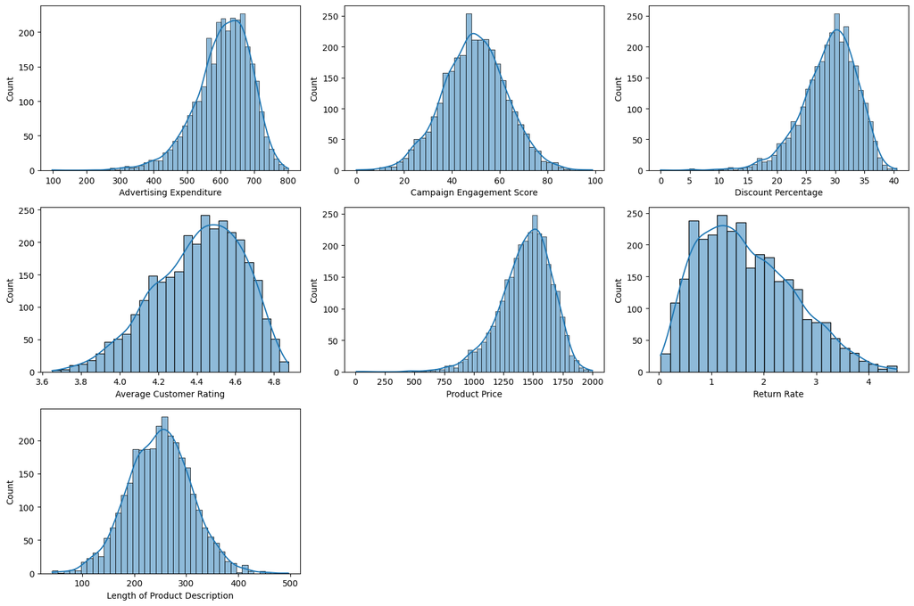

```python
#defining the figure size
plt.figure(figsize=(15, 10))

#defining the list of numerical features to plot
features = data.select_dtypes(include=['number']).columns.tolist()[:-1] # Exclude 'Sales' for now as it's the target variable

#creating the Histograms
for i, feature in enumerate(features):
  plt.subplot(3, 3, i+1) #assign a subplot in the main plot
  sns.histplot(data=data, x=feature, kde=True) #plot the histogram

plt.tight_layout() # to add spacing between the plot
plt.show()

plt.savefig('output.jpeg', bbox_inches='tight')
```

### The line features = data.select_dtypes(include=['number']).columns.tolist()[:-1] is a clever way to select all your numerical 'input' columns while excluding the 'answer' column.

### Here is how it breaks down:

### select_dtypes(include=['number']): This finds every column that contains numbers (like Advertising Expenditure, Price, etc.).

### .columns.tolist(): This turns those column names into a simple list of strings.

### [:-1]: This is a Python 'slice' that means 'start from the beginning and stop right before the last item'.

### In the dataset, 'Sales' is the very last numerical column. By using [:-1], we are telling the computer: 'Give me a list of all numerical factors, but leave out Sales so I can analyze the predictors separately.'

- Sales, Advertising Expenditure, Discount Percentage, and Product Price exhibit left-skewed distributions.
- Return Rate exhibits a right-skewed distribution.
- Campaign Engagement Score and Length of Product Description are approx. normally distributed.

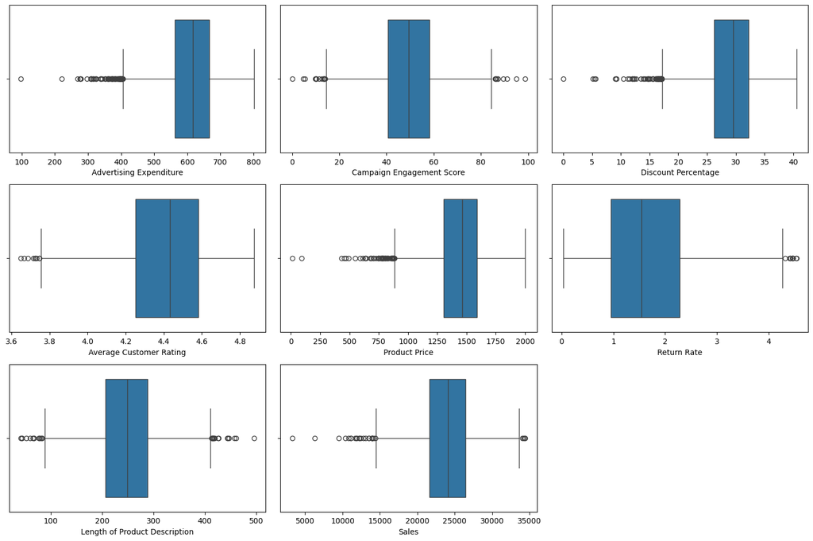

```python
# defining the figure size
plt.figure(figsize=(15,10))

#defining the list of numerical features to plot
features = data.select_dtypes(include='number').columns.tolist()

#creating the histograms
for i, feature in enumerate(features):
  plt.subplot(3, 3, i+1) #assign a subplot in the main plot
  sns.boxplot(data=data, x=feature) #plot the histogram

plt.tight_layout() #to add spacing between plots
plt.show()

plt.savefig('output.jpeg', bbox_inches='tight')
```

- There are outliers in all the attributes in the data.

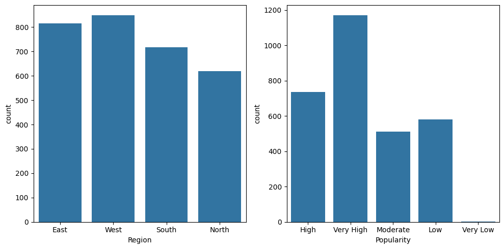

```python
#defining the figure size
plt.figure(figsize=(10, 5))

# defining the list of categorical features to plot
features = data.select_dtypes(exclude=['number']).columns.tolist()

# creating the histogram
for i, feature in enumerate(features):
  plt.subplot(1, 2, i+1) #assign a subplot to the main plot
  sns.countplot(data=data, x=feature) #plot the histogram

plt.tight_layout() #to add spacing before plots
plt.show()
plt.savefig('output.jpeg', bbox_inches='tight')
```

### The code features = data.select_dtypes(exclude=['number']).columns.tolist() is used to automatically identify all categorical (non-numerical) columns in the dataset.

### select_dtypes(exclude=['number']): This filters the DataFrame to only include columns that aren't integers or floats (typically 'object' or 'category' types like Region and Popularity).

### .columns: This extracts the names of those identified columns.

### .tolist(): This converts those names into a clean Python list.

### This is a smart way to prepare the data for categorical visualizations like Count Plots without having to manually type out every column name.

# Bivariate Analysis

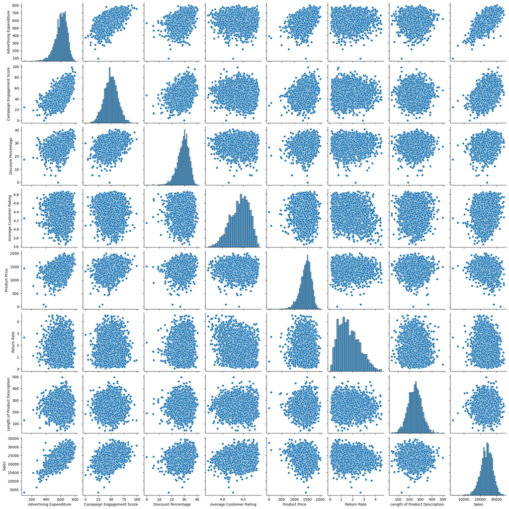

```python
sns.pairplot(data);
plt.savefig('output.jpeg', bbox_inches='tight')
```

### The sns.pairplot(data) output provides a grid of scatter plots and histograms that visualize every possible pair of numerical variables in your dataset.

### Looking at the row for Sales, you can see clear linear patterns emerging:

### Positive Slopes: As Advertising Expenditure or Campaign Engagement Score increases, the dots for Sales tend to move upward.

### Negative Slopes: For Product Price or Return Rate, the dots generally move downward as those values increase.

### The diagonal of the grid shows the Histogram for each individual variable, helping you quickly identify the distribution shape (skewed or normal) for things like Sales or Product Price.

- Sales seem to be positively correlated with Advertising Expenditure, Campaign Engagement Score, and Average Customer Rating.
- Sales seem to be negatively correlated with Product Price and Return Rate.

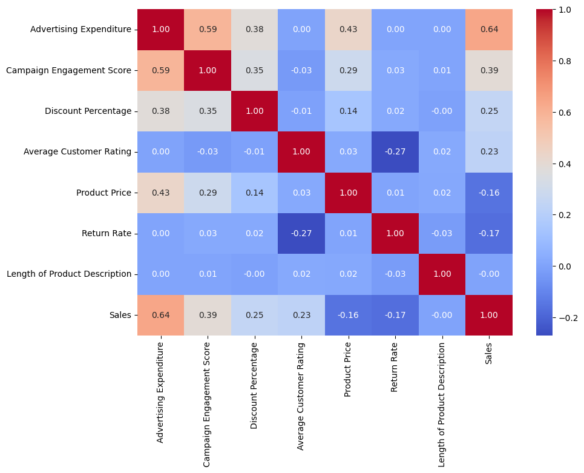

```python
# defining the figure size
plt.figure(figsize=(10, 7))

# plotting the correlation heatmap
sns.heatmap(data.corr(numeric_only = True), annot=True, fmt='0.2f', cmap='coolwarm');

plt.savefig('output.jpeg', bbox_inches='tight')
```

### The correlation heatmap is a powerful visual tool that shows how strongly each pair of numerical variables is related to one another.

### Looking at the 'Sales' row/column, you'll see a strong positive correlation (0.64) with Advertising Expenditure, indicating it's a primary driver of revenue.

### Conversely, you might notice negative correlations with Product Price and Return Rate, which makes sense: higher prices and more returns typically lower total sales revenue. The values range from -1 to 1, where 1 is a perfect positive relationship, -1 is perfect negative, and 0 means no relationship at all.

- Sales is indeed highly positively correlated with Advertising Expenditure.
- Sales are indeed negatively correlated with Product Price and Return Rate, but the strength of the correlation is low.
- Advertising Expenditure and Campaign Engagement Score are positively correlated.
- Return Rate and Average Customer Rating are negatively correlated.

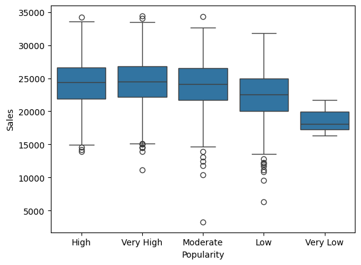

```python
sns.boxplot(data=data, y='Sales', x='Popularity');

plt.savefig('output.jpeg', bbox_inches='tight')
```

### The boxplot for Sales vs. Popularity highlights a clear trend: products with higher popularity ratings generally achieve higher sales.

### Key observations include:

### Positive Trend: As we move from 'Very Low' to 'Very High' popularity, the median sales (the line inside the box) and the overall box positions shift upwards.

### Lower Sales for Unpopular Products: The 'Very Low' and 'Low' categories show significantly lower sales distributions compared to the 'High' and 'Very High' categories.

### Business Insight: This confirms that consumer popularity is a strong driver of revenue for the retailer, which is why it was later included as a key feature in the regression models.

- We observe lower sales for unpopular products.

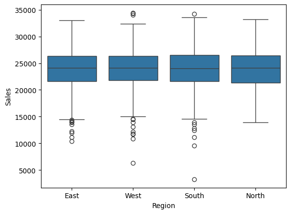

```python
sns.boxplot(data=data, y='Sales', x='Region');

plt.savefig('output.jpeg', bbox_inches='tight')
```

- Sales seem to be uniform across different regions.

### The boxplot for Sales vs. Region shows how revenue is distributed across different geographical areas.

### Looking at the plot, you'll notice that the median lines and the 'boxes' (interquartile ranges) are at very similar heights for North, South, East, and West. This indicates that Sales are remarkably uniform across all regions, suggesting that the retailer's performance isn't heavily dependent on a specific location.

# Data Preparation for Modeling

```python
# defining the explanatory (independent) and response (dependent) variables
X = data.drop('Sales', axis=1)
y = data['Sales']
```

### This step is where we divide the data into two distinct parts required for supervised machine learning:

### X = data.drop('Sales', axis=1): This creates the Explanatory (Independent) Variables. We take the entire dataset and 'drop' the Sales column. The remaining 9 columns (like Price, Ads, etc.) are the 'features' the model uses to make predictions.

### y = data['Sales']: This creates the Response (Dependent) Variable. We isolate just the Sales column, which is the 'target' or the 'answer' the model is trying to learn how to calculate.

### Separating them this way is standard practice so the model knows exactly what to look at (X) and what it is trying to predict (y).

```python
#splitting the data in 80:20 ratio for train and test sets
X_train, X_test, y_train, y_test = train_test_split(
    X,  #specifying the independent variables
    y,  #specifying the dependent variable
    test_size=0.02, #specifying the size of the test set as a fraction of the whole data
    random_state=42 #specifying a seed value to enable reproducible results
)
```

# Model Building

## Simple Linear Regression - Sales Vs Advertising Expenditure

```python
#Defining the independent variable
ind_vars1 = ['Advertising Expenditure']
```

### The variable ind_vars1 is a simple Python list containing the string 'Advertising Expenditure'. Its primary function is to act as a feature selector for the first model.

### When we write X_train[ind_vars1], we are telling the computer to 'only look at the Advertising Expenditure column' and ignore everything else. This allows the lin_reg1 model to focus specifically on how marketing spend alone impacts the total sales, without the interference of other factors like price or discounts.

```python
#creating an instance of linear regression model
lin_reg1 = LinearRegression()

#fitting the model to train the data
lin_reg1.fit(X_train[ind_vars1], y_train)
```

```
LinearRegression()
```

```python
#printiing the linear regression coefficients
print(
    'Slope:', lin_reg1.coef_,
    'intercept:', lin_reg1.intercept_,
)
```

```
Slope: [28.0033902] intercept: 6848.271314790989
```

### The output of lin*reg1.coef* and lin*reg1.intercept* provides the two key numbers that define the mathematical relationship between Advertising Expenditure and Sales:

### Slope (28.00): This is the coef_. It tells us the impact of advertising. For every one dollar we spend on advertising, the model predicts that Sales will increase by approximately $28.00.

### Intercept (6,848.27): This is the intercept_. It represents the 'baseline' sales. If the advertising expenditure were zero, the model predicts we would still have approximately $6,848.27 in sales.

```python
#printing the linear regression equation
print(
    'Sales =',
    '(', lin_reg1.coef_[0],'*', ind_vars1[0],
    '+', lin_reg1.intercept_,
)
```

[output not shown]

### The output of lin*reg1.coef* represents the Slope of our first linear regression model.

### In this specific analysis, the value is approximately 28.00.

### This means every one dollar increase in Advertising Expenditure will lead to $28.00 increase in Sales.

### This coefficient mathematically defines the strength of the relationship between the marketing spend and the resulting revenue; the higher this number, the more impact each advertising dollar has on the total sales.

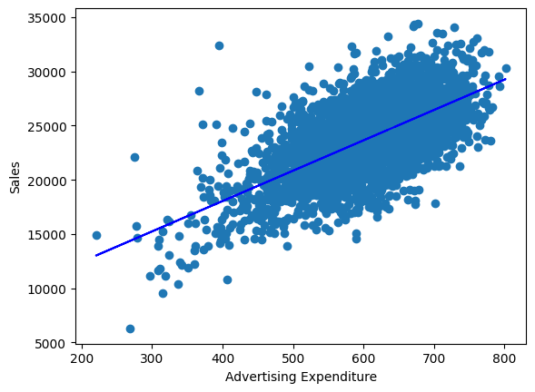

```python
#plotting the best-fit line
fitted_values = lin_reg1.predict(X_train[ind_vars1])

#plot the scatterplot and regression line
plt.scatter(X_train[ind_vars1], y_train)
plt.plot(X_train[ind_vars1], fitted_values, color='blue')
plt.xlabel(ind_vars1[0])
plt.ylabel('Sales')
plt.show()
plt.savefig('output.jpeg', bbox_inches='tight')
```

### The output fitted_values contains the predicted sales for every data point in the training set, calculated by your first model (lin_reg1).

### By running lin_reg1.predict(X_train[ind_vars1]), the model uses its learned formula—Sales = (28.00 × Advertising) + 6848.27—to estimate what sales 'should' be based solely on advertising spend. In the plot, these predictions form the straight blue line. The closer the actual data points (the dots) are to this line, the better advertising expenditure is at predicting the total sales.

## Simple Linear Regression - Sales Vs Discount Percentage

```python
#defining the independent variable
ind_vars2 = ['Discount Percentage']
```

### The variable ind_vars2 is a simple Python list that contains the string 'Discount Percentage'.

### Its main job is to act as a selector for our model. When we use X_train[ind_vars2], we are telling the computer to 'only look at the Discount Percentage column' and ignore everything else. This allows us to train the lin_reg2 model specifically on discounts to see how they alone impact sales, without the interference of other factors like price or advertising.

```python
#creating an instance of the linear regression model
lin_reg2 = LinearRegression()
```

### The function lin_reg2 is an instance of the LinearRegression class from the scikit-learn library.In this specific notebook, it represents the second model, which focuses on predicting Sales using only the Discount Percentage as an input.

### I used lin_reg2.fit() to 'train' the model, which means it analyzed the data to find the line that best fits the relationship between discounts and sales. This allowed us to calculate the specific Slope and Intercept values that define how much sales typically increase when a discount is applied.

```python
#fitting the model to training data
lin_reg2.fit(X_train[ind_vars2], y_train)
```

```
LinearRegression()
```

```python
#printing the linear regression coefficients
print(
    'Slope:', lin_reg2.coef_,
    'Intercept:', lin_reg2.intercept_,
)
```

```
Slope: [189.90544393] Intercept: 18374.963330976447
```

### The output of lin*reg2.coef* and lin*reg2.intercept* defines the mathematical relationship between Discount Percentage and Sales in your second model:

### Slope (189.91): This represents the change in Sales for every 1% increase in Discount Percentage. For each additional percent of discount offered, the model predicts an average increase of approximately $189.91 in Sales.

### Intercept (18,374.96): This is the 'baseline' sales figure. It represents the predicted Sales if the Discount Percentage were zero.

### Combined, the formula for this model is: $Sales = (189.91 \times Discount\%) + 18,374.96$$Sales = (189.91 \times Discount\%) + 18,374.96$.

```python
#printing the linear regression equation
print(
    'Sales =',
    '(', lin_reg2.coef_[0], ')' '*', ind_vars2[0],
    '+', lin_reg2.intercept_,
)
```

```
Sales = ( 189.90544393373395 )* Discount Percentage + 18374.963330976447
```

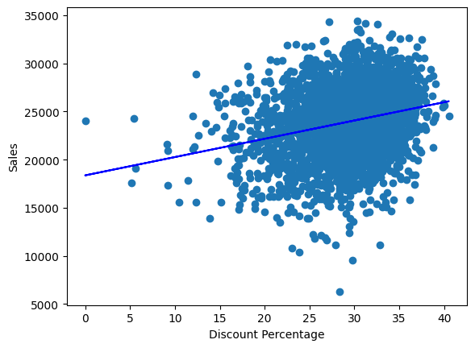

```python
#plotting the best-fit line
fitted_values2 = lin_reg2.predict(X_train[ind_vars2])

#plot the scatterplot and regression line
plt.scatter(X_train[ind_vars2], y_train)
plt.plot(X_train[ind_vars2], fitted_values2, color='blue')
plt.xlabel(ind_vars2[0])
plt.ylabel('Sales')
plt.show()
plt.savefig('output.jpeg', bbox_inches='tight')
```

## Simple Linear Regression - Sales Vs Product Price

```python
#defining the independent variable
ind_vars3 = ['Product Price']
```

```python
#creating an instance of the linear regression model
lin_reg3 = LinearRegression()

#fitting the model to the training data
lin_reg3.fit(X_train[ind_vars3], y_train)
```

```
LinearRegression()
```

```python
#printing the linear regression coefficients
print(
    'Slope:', lin_reg3.coef_,
    'Intercept:', lin_reg3.intercept_,
)
```

```
Slope: [-2.54473242] Intercept: 27535.010956684433
```

```python
#printing the linear regression equation
print(
    'Sales =',
    '(', lin_reg3.coef_[0], '(', '*', ind_vars3[0],
    '+', lin_reg3.intercept_,
)
```

```
Sales = ( -2.5447324177073467 ( * Product Price + 27535.010956684433
```

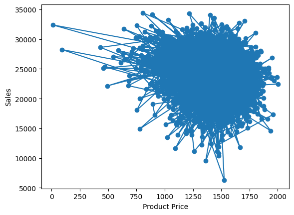

```python
#plotting the best-fit line
fitted_values3  = lin_reg3.predict(X_train[ind_vars3])

#plot the scatterplot and regression line
plt.scatter(X_train[ind_vars3], y_train)
plt.plot(X_train[ind_vars3], y_train)
plt.xlabel(ind_vars3[0])
plt.ylabel('Sales')
plt.show()
plt.savefig('output.jpeg', bbox_inches='tight')
```

### The output fitted_values3 is an array of predicted values generated by the model lin_reg3.

### Specifically, when we run

### lin_reg3.predict(X_train[ind_vars3]), the model takes the Product Price for every item in your training set and applies the linear equation ($Sales = Slope \times Price + Intercept$$Sales = Slope \times Price + Intercept$) to calculate an estimated sales figure.

# Multiple Linear Regression - Sales Vs Advertising Expenditure, Discount Percentage

```python
#defining the independent variables
ind_vars4 = ['Advertising Expenditure', 'Discount Percentage']
```

### The variable ind_vars4 is a Python list that defines the subset of features used for the fourth linear regression model (lin_reg4). It specifically includes Advertising Expenditure and Discount Percentage. By using X_train[ind_vars4], we slice the training data to focus only on these two predictors, allowing us to evaluate how these two specific factors interact to influence sales before adding more complex variables like Product Price or Popularity.

```python
# creating an instance of the linear regression model
lin_reg4 = LinearRegression()

# fitting the model to the training data
lin_reg4.fit(X_train[ind_vars4], y_train)
```

```
LinearRegression()
```

```python
#printing the linear regression coefficients
print(
    'Coefficients:', lin_reg4.coef_,
    lin_reg4.intercept_,
)
```

```
Coefficients: [27.95301816  2.26439341] 6813.233296242037
```

### Discount Percentage (2.26): For every 1% increase in discount, sales are expected to increase by approximately $2.26.

### Intercept (6,813.23): This is the baseline sales value predicted by this specific model if both advertising and discounts were zero.

### In this model configuration, both factors show a positive relationship with total sales.

```python
# printing the linear regression equation
print(
    'Sales =',
    '(', lin_reg4.coef_[0], ')', '*', ind_vars4[0],
    '+ (', lin_reg4.coef_[1], ')', '*', ind_vars4[1],
    '+', lin_reg4.intercept_,
)
```

```
Sales = ( 27.953018160096892 ) * Advertising Expenditure + ( 2.264393411648115 ) * Discount Percentage + 6813.233296242037
```

# Multiplt Linear Regression - Sales Vs Advertising Expenditure, Discount Percentage, Product Price

```python
#defining the independent variables
ind_vars5 = ['Advertising Expenditure', 'Discount Percentage', 'Product Price']
```

### The variable ind_vars5 is a Python list used to select a specific subset of features for training the fifth linear regression model (lin_reg5).

### It contains the following columns:

### Advertising Expenditure

### Discount Percentage

### Product Price

### By using X_train[ind_vars5], the code ensures that the model only considers these three specific variables. This allows for step-by-step experimentation to see how adding Product Price affects the model's accuracy compared to previous versions that used fewer features.

```python
# creating an instance of the linear regression model
lin_reg5 = LinearRegression()

# fitting the model to the training data
lin_reg5.fit(X_train[ind_vars5], y_train)
```

```
LinearRegression()
```

```python
# printing the linear regression coefficients
print(
    'Coefficients:', lin_reg5.coef_,
    lin_reg5.intercept_,
)
```

```
Coefficients: [38.32378577 -7.11016964 -8.58347708] 13093.729277861
```

### The output of lin*reg5.coef* and lin*reg5.intercept* represents the specific mathematical weights the fifth model assigned to each feature.

### Coefficients (Weights): Each number corresponds to one of the variables in ind_vars5 (Advertising Expenditure, Discount Percentage, and Product Price). A positive coefficient means that as the variable increases, sales are expected to rise, while a negative coefficient indicates that an increase in that variable (like Price) typically leads to a decrease in sales.

### Intercept: This is the baseline sales value ($13,093.73) predicted if all input features were zero.

### In this model, the results show a strong positive impact from Advertising, while both Discount Percentage and Product Price show negative relationships with predicted Sales.

```python
# printing the linear regression equation
print(
    'Sales =',
    '(', lin_reg5.coef_[0], ')', '*', ind_vars5[0],
    '+ (', lin_reg5.coef_[1], ')', '*', ind_vars5[1],
    '+ (', lin_reg5.coef_[2], ')', '*', ind_vars5[2],
    '+', lin_reg5.intercept_,
)
```

```
Sales = ( 38.32378576619314 ) * Advertising Expenditure + ( -7.110169638982491 ) * Discount Percentage + ( -8.583477079285386 ) * Product Price + 13093.729277861
```

### Product Price (-8.58): For every $1 increase in the product's price, sales are predicted to decrease by approximately $8.58.

### These values help the model calculate the final sales forecast by summing these weighted inputs with the intercept.

# Multiple Linear Regression - Sales Vs Advertising Expenditure, Discount Percentage, Product Price, Popularity

We first need to label encode the `Popularity` column.

```python
# defining the label encoding
label_enc = {
    'Very Low': 1,
    'Low': 2,
    'Moderate': 3,
    'High': 4,
    'Very High': 5,
}
```

### The label_enc variable is a Python dictionary used to perform Ordinal Encoding on the Popularity column.

### Since popularity has a natural order (e.g., 'Very Low' is less than 'Low'), we assign each category a specific number from 1 to 5. This allows the linear regression model to understand that 'Very High' (5) represents a greater value than 'Moderate' (3), which wouldn't be possible if the data remained as text strings.

```python
# Re-initialize X from the original data to ensure 'Popularity' is in string format
X = data.drop('Sales', axis=1)

# encoding the popularity column
X['Popularity'] = X['Popularity'].map(
    lambda x: label_enc[x]
)

X.head()
```

|  | Advertising Expenditure | Campaign Engagement Score | Discount Percentage | Average Customer Rating | Product Price | Return Rate | Length of Product Description | Region | Popularity |
| --- | --- | --- | --- | --- | --- | --- | --- | --- | --- |
| 0 | 644.049317 | 54.565531 | 25.267151 | 4.604634 | 1599.575723 | 2.133580 | 231.185389 | East | 4 |
| 1 | 521.483294 | 46.875226 | 35.075859 | 4.358693 | 1586.464404 | 1.553437 | 262.686931 | West | 5 |
| 2 | 540.079510 | 42.287145 | 12.618381 | 4.571018 | 1301.644856 | 2.274891 | 324.347319 | South | 5 |
| 3 | 627.938419 | 61.825441 | 31.588445 | 4.234209 | 1601.041884 | 1.035971 | 447.710984 | South | 5 |
| 4 | 471.149948 | 31.061512 | 9.198991 | 4.816215 | 1496.734345 | 3.276840 | 310.055333 | East | 3 |

### Label Encoding: The Popularity column has been converted from text (e.g., 'High', 'Moderate') into numerical ranks (e.g., 4.0, 3.0) so the model can process it.

```python
# splitting the data in 80:20 ratio for train and test sets
X_train, X_test, y_train, y_test = train_test_split(
    X,  #specifying the independent variables
    y,  #specifying the dependent variable
    test_size=0.02, #specifying the size of the test set as a fraction of the whole data
    random_state=42  #specifying a seed value to enable reproducible results
)
```

```python
# defining the independent variables
ind_vars6 = ['Advertising Expenditure', 'Discount Percentage', 'Product Price', 'Popularity']
```

### The variable ind_vars6 is a Python list that acts as a selector for specific features (independent variables) used to train the sixth iteration of the regression model (lin_reg6).

### In this specific case, it contains:

### Advertising Expenditure

### Discount Percentage

### Product Price

### Popularity (which was label-encoded just before this step)

### By defining this list, we can easily pass only these four columns from the training and testing DataFrames (e.g., X_train[ind_vars6]) into the model's .fit() and .predict() methods. This allows for an incremental approach to model building, where we can compare how adding 'Popularity' improves the model's performance compared to previous versions that only used the first three variables.

```python
# creating an instance of the linear regression model
lin_reg6 = LinearRegression()

# fitting the model to the training data
lin_reg6.fit(X_train[ind_vars6], y_train)
```

```
LinearRegression()
```

```python
# printing the linear regression coefficients
print(
    'Sales =',
    '(', lin_reg6.coef_[0], ')', '*', ind_vars6[0],
    '+ (', lin_reg6.coef_[1], ')', '*', ind_vars6[1],
    '+ (', lin_reg6.coef_[2], ')', '*', ind_vars6[2],
    '+ (', lin_reg6.coef_[3], ')', '*', ind_vars6[3],
)
```

```
Sales = ( 38.151809786112516 ) * Advertising Expenditure + ( -5.795504307664052 ) * Discount Percentage + ( -8.644389635806558 ) * Product Price + ( 562.9764378021691 ) * Popularity
```

### Product Price (-8.64): The negative coefficient indicates that as the price increases, sales tend to decrease slightly (by about $8.64 for every $1 increase in price).

# Multiple Linear Regression - Sales Vs All Independent Variables

We first need to one-hot encode the `Region` column.

```python
# creating one-hot enclosed (also called dummy) variables
X = pd.get_dummies(
    X,  #defining the dataframe from where to fetch the data
    columns=X.select_dtypes(include=['object', 'category']).columns.tolist(), #defining the types of columnsfor which dummies will be made
    drop_first=True, #dropping the first dummy column
)

# specifying the datatype of the independent variables dataframe
X = X.astype(float)

X.head()
```

|  | Advertising Expenditure | Campaign Engagement Score | Discount Percentage | Average Customer Rating | Product Price | Return Rate | Length of Product Description | Popularity | Region_North | Region_South | Region_West |
| --- | --- | --- | --- | --- | --- | --- | --- | --- | --- | --- | --- |
| 0 | 644.049317 | 54.565531 | 25.267151 | 4.604634 | 1599.575723 | 2.133580 | 231.185389 | 4.0 | 0.0 | 0.0 | 0.0 |
| 1 | 521.483294 | 46.875226 | 35.075859 | 4.358693 | 1586.464404 | 1.553437 | 262.686931 | 5.0 | 0.0 | 0.0 | 1.0 |
| 2 | 540.079510 | 42.287145 | 12.618381 | 4.571018 | 1301.644856 | 2.274891 | 324.347319 | 5.0 | 0.0 | 1.0 | 0.0 |
| 3 | 627.938419 | 61.825441 | 31.588445 | 4.234209 | 1601.041884 | 1.035971 | 447.710984 | 5.0 | 0.0 | 1.0 | 0.0 |
| 4 | 471.149948 | 31.061512 | 9.198991 | 4.816215 | 1496.734345 | 3.276840 | 310.055333 | 3.0 | 0.0 | 0.0 | 0.0 |

### The function pd.get_dummies() is used to perform one-hot encoding on categorical variables like Region.

### In machine learning, models require numerical inputs. pd.get_dummies takes a column with text categories (like 'North', 'South', 'West', 'East') and creates a new column for each category.

### New Columns: It adds Region_North, Region_South, and Region_West to the data.

### Binary Values: These columns contain 1 if the product belongs to that region and 0 otherwise.

### drop_first=True: This is a crucial step. It removes one of the categories (in this case, 'East'). We do this to avoid the 'dummy variable trap' (multi-collinearity), as the 'East' region is now represented when all other region columns are 0.

### Essentially, this turns the descriptive text into a mathematical format the linear regression model can understand.

- Note that the dummy variable corresponding to the '*East*' category has been dropped.

```python
# splitting the data into 80:20 ratio for train and test sets
X_train, X_test, y_train, y_test = train_test_split(
    X,  #specifying the independent variables
    y,  #specifying the dependent variables
    test_size=0.20,  #specifying the size of the test set as a fraction of the whole data
    random_state=42, #specifying a seed value to enable reproducible results
)
```

```python
# creating an instance of the linear regression model
lin_reg7 = LinearRegression()

# fitting the model to the training data
lin_reg7.fit(X_train, y_train)
```

```
LinearRegression()
```

```python
# printing the linear regression coefficients
print(
    'Coefficients:', lin_reg7.coef_,
    lin_reg7.intercept_,
)
```

```
Coefficients: [ 3.68003768e+01  2.07776337e+01 -6.91846629e+00  2.89027810e+03
 -8.67003378e+00 -4.44787734e+02 -5.08833857e-02  1.46842283e+02
 -6.98114448e+00  5.28817618e+01  1.89167361e+02] 469.5990299012665
```

### The output of lin*reg7.coef* and lin*reg7.intercept* defines the mathematical formula the model uses to forecast sales.

### Coefficients (lin*reg7.coef*): These represent the 'weight' or impact of each independent variable. For every one-unit increase in a feature (like Advertising Expenditure), the sales are expected to change by the amount of its corresponding coefficient, assuming all other variables stay the same.

### Positive coefficients (like Advertising Expenditure or Customer Rating) mean the variable helps increase sales.

### Negative coefficients (like Product Price or Return Rate) mean the variable tends to decrease sales.

### Intercept (lin*reg7.intercept*): This is the 'baseline' value. It represents the predicted sales amount if all the independent variables were zero.

### In short, the coefficients tell you the strength and direction of the relationship between each factor and your sales, while the intercept provides the starting point of the prediction.

```python
#printing the linear regression equation
equation = 'Sales = (' + str(lin_reg7.coef_[0]) + ') * ' + X_train.columns.tolist()[0]

for i in range(1, len(lin_reg7.coef_)):
  equation += ' + (' + str(lin_reg7.coef_[i]) + ') * ' + X_train.columns.tolist()[i]

equation += ' + ' + str(lin_reg7.intercept_)

print(equation)
```

[output not shown]

## This equation shows the relationship between Sales and all the input features. The coefficients indicate how much Sales are expected to change for a one-unit increase in each respective variable, holding other variables constant. For instance:

### A one-unit increase in 'Advertising Expenditure' is associated with an increase of approximately 36.8 in 'Sales'.

### Average Customer Rating' has a strong positive impact, with a one-unit increase leading to about 2890 increase in 'Sales'.

### 'Product Price' and 'Return Rate' have negative coefficients, suggesting that as these increase, 'Sales' tend to decrease.

### The regional dummy variables (Region_North, Region_South, Region_West) indicate the impact of being in those regions compared to the 'East' region (which was dropped as the baseline).

# Model Evaluation

We first define a set of utility functions to compute MAPE and Adjusted $R^2$, and another one to collate all the metrics into a single dataframe.

```python
#function to compute MAPE
def mape_score(targets, predictions):
  return np.mean(np.abs(targets - predictions) / targets) * 100

# function to compute adjusted R-squared
def adj_r2_score(predicators, targets, predictions):
  r2 = r2_score(targets, predictions)
  n = predicators.shape[0]
  k = predicators.shape[1]
  return 1 - ((1 - r2) * (n - 1) / (n - k - 1))

# function to compute different metrics to check performance of a regression model
def model_performance_regression(model, predicators, target):
  '''
  function to compute different meterics to check regression model performance

  model: regression model
  predicators: independent variables
  target: dependent variable
  '''

  #predicting using the independent variables
  pred = model.predict(predicators)

  rmse = np.sqrt(mean_squared_error(target, pred)) # to compute RMSE
  mae = mean_absolute_error(target, pred) # to compute MAE
  mape = mape_score(target, pred) # to compute MAPE
  r2 = r2_score(target, pred) # to compute R-squared
  adj_r2 = adj_r2_score(predicators, target, pred) # to compute Adjusted R-squared

  # creating a dataframe of metrics
  df_perf = pd.DataFrame(
      {
          'RSME': rmse,
          'MAE': mae,
          'MAPE': mape,
          'R-squared': r2,
          'Adj R-squared': adj_r2,
                },
      index=[0],
  )
  return df_perf
```

### mape_score(targets, predictions): This calculates the Mean Absolute Percentage Error. It finds the absolute difference between actual and predicted values, divides by the actual values to get a percentage, and returns the average. It's great for understanding the error relative to the scale of the data.

### adj_r2_score(predicators, targets, predictions): This calculates the Adjusted R-squared. Unlike standard R-squared, this penalizes the score for adding independent variables (predictors) that don't improve the model significantly. It ensures that the model's complexity is justified.

### model_performance_regression(model, predicators, target): This is a wrapper function. It takes the trained model and data, generates predictions, and then calls several metrics (RMSE, MAE, MAPE, R2, and Adj R2) to get a complete picture of how the model is performing.

### return df_perf: This is the final statement inside the model_performance_regression function. It returns all the calculated metrics organized neatly into a single-row Pandas DataFrame, making it easy to display or concatenate with results from other models.

We'll now check the performance of all the models we've built so far.

# Simple Linear Regression - Sales Vs Advertising Expenditure

```python
lin_reg1_train_perf = model_performance_regression(lin_reg1, X_train[ind_vars1], y_train)
lin_reg1_train_perf
```

|  | RSME | MAE | MAPE | R-squared | Adj R-squared |
| --- | --- | --- | --- | --- | --- |
| 0 | 2753.957368 | 2208.194334 | 9.663531 | 0.415554 | 0.41531 |

## The performance metrics for the simple linear regression model with 'Advertising Expenditure' as the independent variable are as follows:

### MAPE (Mean Absolute Percentage Error): 9.66% - On average, the predictions are off by approximately 9.66% of the actual sales value.

### R-squared: 0.4155 - This suggests that about 41.55% of the variance in 'Sales' can be explained by 'Advertising Expenditure'.

### Adjusted R-squared: 0.4153 - Similar to R-squared, this value also indicates that around 41.53% of the variance in 'Sales' is explained by the model, adjusted for the single predictor.

### Overall, the model explains a moderate portion of the variance in sales using only advertising expenditure.

```python
lin_reg1_test_perf = model_performance_regression(lin_reg1, X_test[ind_vars1], y_test)
lin_reg1_test_perf
```

|  | RSME | MAE | MAPE | R-squared | Adj R-squared |
| --- | --- | --- | --- | --- | --- |
| 0 | 2854.132259 | 2225.815319 | 9.981796 | 0.386882 | 0.385857 |

### MAE (2225.82): This means the average absolute difference between the predicted and actual sales values is about $2,225.82.

### MAPE (9.98%): On average, the predictions are off by approximately 9.98% of the actual sales value.

### R-squared (0.3869): This suggests that about 38.69% of the variance in Sales can be explained by Advertising Expenditure alone.

### Adjusted R-squared (0.3859): This value confirms that around 38.59% of the variance is explained, accounting for the single predictor.

### Overall, while Advertising Expenditure is a significantly better predictor than Discount Percentage (which only explained ~6.5%), it still leaves about 61% of the variance in sales unexplained, suggesting that other factors are also important.

# Simple Linear Regression - Sales Vs Discount Percentage

```python
lin_reg2_train_perf = model_performance_regression(lin_reg2, X_train[ind_vars2], y_train)
lin_reg2_train_perf
```

|  | RSME | MAE | MAPE | R-squared | Adj R-squared |
| --- | --- | --- | --- | --- | --- |
| 0 | 3489.781607 | 2761.567382 | 12.467055 | 0.061517 | 0.061126 |

### MAPE (Mean Absolute Percentage Error): 12.47% - On average, the predictions are off by approximately 12.47% of the actual sales value.

### R-squared: 0.0615 - This suggests that only about 6.15% of the variance in 'Sales' can be explained by 'Discount Percentage'.

### Adjusted R-squared: 0.0611 - Similar to R-squared, this value also indicates that around 6.11% of the variance in 'Sales' is explained by the model, adjusted for the single predictor.

### Compared to the model with 'Advertising Expenditure', this model explains a much smaller portion of the variance in sales, indicating that 'Discount Percentage' alone is not a strong predictor of sales.

```python
lin_reg2_test_perf = model_performance_regression(lin_reg2, X_test[ind_vars2], y_test)
lin_reg2_test_perf
```

|  | RSME | MAE | MAPE | R-squared | Adj R-squared |
| --- | --- | --- | --- | --- | --- |
| 0 | 3524.552562 | 2797.35172 | 13.33677 | 0.065017 | 0.063454 |

### MAE (2797.35): The average absolute difference between predicted and actual sales is $2,797.35.

### MAPE (13.34%): The predictions are, on average, 13.34% off from the actual sales values.

### R-squared (0.065): This is the most critical metric here; it shows that only 6.5% of the variance in Sales can be explained by the Discount Percentage alone.

### Adj R-squared (0.063): Adjusting for the number of predictors, it confirms that this single feature has very low predictive power.

### In summary, Discount Percentage alone is a poor predictor of sales, as indicated by the high error rates and the very low R-squared value.

# Simple Linear Regression - Sales Vs Product Price

```python
lin_reg3_train_perf = model_performance_regression(lin_reg3, X_train[ind_vars3], y_train)
lin_reg3_train_perf
```

|  | RSME | MAE | MAPE | R-squared | Adj R-squared |
| --- | --- | --- | --- | --- | --- |
| 0 | 3558.438736 | 2816.224505 | 12.760239 | 0.024227 | 0.02382 |

```python
lin_reg3_test_perf = model_performance_regression(lin_reg3, X_test[ind_vars3], y_test)
lin_reg3_test_perf
```

|  | RSME | MAE | MAPE | R-squared | Adj R-squared |
| --- | --- | --- | --- | --- | --- |
| 0 | 3601.725773 | 2843.525597 | 13.7018 | 0.023625 | 0.021992 |

### MAE (Mean Absolute Error): 2843.53 - This means the average absolute difference between the predicted and actual sales values is about $2844.

### MAPE (Mean Absolute Percentage Error): 13.70% - On average, the predictions are off by approximately 13.70% of the actual sales value.

### R-squared: 0.0236 - This suggests that only about 2.36% of the variance in 'Sales' can be explained by 'Product Price'.

### Adjusted R-squared: 0.0220 - Similar to R-squared, this value also indicates that around 2.20% of the variance in 'Sales' is explained by the model, adjusted for the single predictor.

### Similar to the 'Discount Percentage' model, this model explains a very small portion of the variance in sales, suggesting that 'Product Price' alone is not a strong predictor of sales.

# Multiple Linear Regression - Sales Vs Advertising Expenditure, Discount Percentage

```python
lin_reg4_train_perf = model_performance_regression(lin_reg4, X_train[ind_vars4], y_train)
lin_reg4_train_perf
```

|  | RSME | MAE | MAPE | R-squared | Adj R-squared |
| --- | --- | --- | --- | --- | --- |
| 0 | 2754.001957 | 2208.160933 | 9.663599 | 0.415535 | 0.415047 |

### The performance metrics for the multiple linear regression model (lin_reg4) with 'Advertising Expenditure' and 'Discount Percentage' as independent variables on the training data are as follows:

### RMSE (Root Mean Squared Error): 2754.00 - This indicates that, on average, the model's predictions deviate from the actual sales by approximately $2754.

### MAE (Mean Absolute Error): 2208.16 - This means the average absolute difference between the predicted and actual sales values is about $2208.

### MAPE (Mean Absolute Percentage Error): 9.66% - On average, the predictions are off by approximately 9.66% of the actual sales value.

### R-squared: 0.4155 - This suggests that about 41.55% of the variance in 'Sales' can be explained by 'Advertising Expenditure' and 'Discount Percentage' combined.

### Adjusted R-squared: 0.4150 - This value indicates that around 41.50% of the variance in 'Sales' is explained by the model, adjusted for the two predictors. This is slightly lower than R-squared, as expected when adding more predictors, but it still shows a similar explanatory power.

### Comparing this to the simple linear regression model with only 'Advertising Expenditure' (lin_reg1_train_perf), the metrics are very similar (RMSE, MAE, MAPE, R-squared, Adjusted R-squared are almost identical). This suggests that 'Discount Percentage', when added to 'Advertising Expenditure', does not significantly improve the model's performance in explaining sales on the training data.

```python
lin_reg4_test_perf = model_performance_regression(lin_reg4, X_test[ind_vars4], y_test)
lin_reg4_test_perf
```

|  | RSME | MAE | MAPE | R-squared | Adj R-squared |
| --- | --- | --- | --- | --- | --- |
| 0 | 2853.798095 | 2225.257448 | 9.979721 | 0.387026 | 0.384972 |

### The performance metrics for the multiple linear regression model (lin_reg4) with 'Advertising Expenditure' and 'Discount Percentage' as independent variables on the test data are as follows:

### RMSE (Root Mean Squared Error): 2853.80 - This indicates that, on average, the model's predictions deviate from the actual sales on the test set by approximately $2854.

### MAE (Mean Absolute Error): 2225.26 - This means the average absolute difference between the predicted and actual sales values on the test set is about $2225.

### MAPE (Mean Absolute Percentage Error): 9.98% - On average, the predictions on the test set are off by approximately 9.98% of the actual sales value.

### R-squared: 0.3870 - This suggests that about 38.70% of the variance in 'Sales' on the test set can be explained by 'Advertising Expenditure' and 'Discount Percentage' combined.

### Adjusted R-squared: 0.3850 - This value indicates that around 38.50% of the variance in 'Sales' on the test set is explained by the model, adjusted for the two predictors.

### Comparing these test metrics to the training metrics for lin_reg4, we see that the performance is quite consistent, indicating that the model is generalizing well to unseen data and is not overfitting. However, similar to the training set performance, adding 'Discount Percentage' to 'Advertising Expenditure' does not significantly improve the model's predictive power over using 'Advertising Expenditure' alone (as seen in lin_reg1_test_perf).

# Multiple Linear Regression - Sales Vs Advertising Expenditure, Discount Percentage, Product Price

```python
lin_reg5_train_perf = model_performance_regression(lin_reg5, X_train[ind_vars5], y_train)
lin_reg5_train_perf
```

|  | RSME | MAE | MAPE | R-squared | Adj R-squared |
| --- | --- | --- | --- | --- | --- |
| 0 | 2170.831165 | 1757.794244 | 7.647061 | 0.636853 | 0.636399 |

### The performance metrics for the multiple linear regression model (lin_reg5) with 'Advertising Expenditure', 'Discount Percentage', and 'Product Price' as independent variables on the training data are as follows:

### RMSE (Root Mean Squared Error): 2170.83 - This indicates that, on average, the model's predictions deviate from the actual sales by approximately $2171.

### MAE (Mean Absolute Error): 1757.79 - This means the average absolute difference between the predicted and actual sales values is about $1758.

### MAPE (Mean Absolute Percentage Error): 7.65% - On average, the predictions are off by approximately 7.65% of the actual sales value.

### R-squared: 0.6369 - This suggests that about 63.69% of the variance in 'Sales' can be explained by 'Advertising Expenditure', 'Discount Percentage', and 'Product Price' combined.

### Adjusted R-squared: 0.6364 - This value indicates that around 63.64% of the variance in 'Sales' is explained by the model, adjusted for the three predictors. This is very close to the R-squared, indicating that the added predictors are contributing positively to the model.

### Comparing this to lin_reg4_train_perf, we observe a significant improvement in performance. The RMSE and MAE have decreased, and the R-squared and Adjusted R-squared values have increased considerably (from around 0.41 to 0.63). This suggests that including 'Product Price' alongside 'Advertising Expenditure' and 'Discount Percentage' has substantially enhanced the model's ability to explain the variance in sales on the training data.

```python
lin_reg5_test_perf = model_performance_regression(lin_reg5, X_test[ind_vars5], y_test)
lin_reg5_test_perf
```

|  | RSME | MAE | MAPE | R-squared | Adj R-squared |
| --- | --- | --- | --- | --- | --- |
| 0 | 2176.25958 | 1737.863242 | 7.652507 | 0.643535 | 0.641741 |

### The performance metrics for the multiple linear regression model (lin_reg5) with 'Advertising Expenditure', 'Discount Percentage', and 'Product Price' as independent variables on the test data are as follows:

### RMSE (Root Mean Squared Error): 2176.26 - This indicates that, on average, the model's predictions deviate from the actual sales on the test set by approximately $2176.

### MAE (Mean Absolute Error): 1737.86 - This means the average absolute difference between the predicted and actual sales values on the test set is about $1738.

### MAPE (Mean Absolute Percentage Error): 7.65% - On average, the predictions on the test set are off by approximately 7.65% of the actual sales value.

### R-squared: 0.6435 - This suggests that about 64.35% of the variance in 'Sales' on the test set can be explained by 'Advertising Expenditure', 'Discount Percentage', and 'Product Price' combined.

### Adjusted R-squared: 0.6417 - This value indicates that around 64.17% of the variance in 'Sales' on the test set is explained by the model, adjusted for the three predictors. This is very close to the R-squared, indicating that the added predictors are contributing positively to the model.

### Comparing these test metrics to the training metrics for lin_reg5, we observe that the performance is consistent, with similar RMSE, MAE, MAPE, R-squared, and Adjusted R-squared values. This indicates that the model is generalizing well to unseen data and is not overfitting. The inclusion of 'Product Price' significantly improved the model's predictive power compared to models with fewer features.

# Multiple Linear Regression - Sales Vs Advertising Expenditure, Discount Percentage, Product Price, Popularity

```python
lin_reg6_train_perf = model_performance_regression(lin_reg6, X_train[ind_vars6], y_train)
lin_reg6_train_perf
```

|  | RSME | MAE | MAPE | R-squared | Adj R-squared |
| --- | --- | --- | --- | --- | --- |
| 0 | 2080.59701 | 1680.589126 | 7.293768 | 0.666416 | 0.665858 |

### The performance metrics for the multiple linear regression model (lin_reg6) with 'Advertising Expenditure', 'Discount Percentage', 'Product Price', and 'Popularity' as independent variables on the training data are as follows:

### RMSE (Root Mean Squared Error): 2080.60 - This indicates that, on average, the model's predictions deviate from the actual sales by approximately $2081.

### MAE (Mean Absolute Error): 1680.59 - This means the average absolute difference between the predicted and actual sales values is about $1681.

### MAPE (Mean Absolute Percentage Error): 7.29% - On average, the predictions are off by approximately 7.29% of the actual sales value.

### R-squared: 0.6664 - This suggests that about 66.64% of the variance in 'Sales' can be explained by the combined influence of 'Advertising Expenditure', 'Discount Percentage', 'Product Price', and 'Popularity'.

### Adjusted R-squared: 0.6659 - This value indicates that around 66.59% of the variance in 'Sales' is explained by the model, adjusted for the four predictors. This is very close to the R-squared, indicating that the added predictors are contributing positively to the model.

### Comparing this to lin_reg5_train_perf, we observe a further improvement in performance. The RMSE and MAE have decreased, and the R-squared and Adjusted R-squared values have increased (from around 0.63 to 0.66). This indicates that including 'Popularity' has further enhanced the model's ability to explain the variance in sales on the training data.

```python
lin_reg6_test_perf = model_performance_regression(lin_reg6, X_test[ind_vars6], y_test)
lin_reg6_test_perf
```

|  | RSME | MAE | MAPE | R-squared | Adj R-squared |
| --- | --- | --- | --- | --- | --- |
| 0 | 2041.729887 | 1635.207755 | 7.142549 | 0.686244 | 0.684135 |

### The performance metrics for the multiple linear regression model (lin_reg6) with 'Advertising Expenditure', 'Discount Percentage', 'Product Price', and 'Popularity' as independent variables on the test data are as follows:

### RMSE (Root Mean Squared Error): 2041.73 - This indicates that, on average, the model's predictions deviate from the actual sales on the test set by approximately $2042.

### MAE (Mean Absolute Error): 1635.21 - This means the average absolute difference between the predicted and actual sales values on the test set is about $1635.

### MAPE (Mean Absolute Percentage Error): 7.14% - On average, the predictions on the test set are off by approximately 7.14% of the actual sales value.

### R-squared: 0.6862 - This suggests that about 68.62% of the variance in 'Sales' on the test set can be explained by the combined influence of these four predictors.

### Adjusted R-squared: 0.6841 - This value indicates that around 68.41% of the variance in 'Sales' on the test set is explained by the model, adjusted for the four predictors. This is very close to the R-squared, indicating that the added predictors are contributing positively to the model.

### Comparing these test metrics to the training metrics for lin_reg6 (lin_reg6_train_perf), we observe that the performance is quite consistent, suggesting that the model is generalizing well to unseen data and is not overfitting. Furthermore, compared to lin_reg5_test_perf, the inclusion of 'Popularity' has led to a noticeable improvement in all metrics (lower RMSE/MAE/MAPE, higher R-squared/Adjusted R-squared), indicating that 'Popularity' is a valuable predictor for sales.

# Multiple Linear Regression - Sales Vs All independent variables

```python
lin_reg7_train_perf = model_performance_regression(lin_reg7, X_train, y_train)
lin_reg7_train_perf
```

|  | RSME | MAE | MAPE | R-squared | Adj R-squared |
| --- | --- | --- | --- | --- | --- |
| 0 | 1940.930335 | 1564.829605 | 6.785088 | 0.709698 | 0.708361 |

### The performance metrics for the multiple linear regression model (lin_reg7) with all independent variables on the training data are as follows:

### RMSE (Root Mean Squared Error): 1940.93 - This indicates that, on average, the model's predictions deviate from the actual sales by approximately $1941.

### MAE (Mean Absolute Error): 1564.83 - This means the average absolute difference between the predicted and actual sales values is about $1565.

### MAPE (Mean Absolute Percentage Error): 6.79% - On average, the predictions are off by approximately 6.79% of the actual sales value.

### R-squared: 0.7097 - This suggests that about 70.97% of the variance in 'Sales' can be explained by the combined influence of all the independent variables.

### Adjusted R-squared: 0.7084 - This value indicates that around 70.84% of the variance in 'Sales' is explained by the model, adjusted for all the predictors. This is very close to the R-squared, indicating that the added predictors are contributing positively to the model.

### Comparing this to lin_reg6_train_perf, we observe a further improvement in performance. The RMSE and MAE have decreased, and the R-squared and Adjusted R-squared values have increased (from around 0.66 to 0.71). This indicates that including the remaining independent variables (such as Campaign Engagement Score, Average Customer Rating, Return Rate, Length of Product Description, and Region dummy variables) has further enhanced the model's ability to explain the variance in sales on the training data.

```python
lin_reg7_test_perf = model_performance_regression(lin_reg7, X_test, y_test)
lin_reg7_test_perf
```

|  | RSME | MAE | MAPE | R-squared | Adj R-squared |
| --- | --- | --- | --- | --- | --- |
| 0 | 1907.839718 | 1558.392467 | 6.763019 | 0.726045 | 0.72092 |

### The performance metrics for the multiple linear regression model (lin_reg7) with all independent variables on the test data are as follows:

### RMSE (Root Mean Squared Error): 1907.84 - This indicates that, on average, the model's predictions deviate from the actual sales on the test set by approximately $1908.

### MAE (Mean Absolute Error): 1558.39 - This means the average absolute difference between the predicted and actual sales values on the test set is about $1558.

### MAPE (Mean Absolute Percentage Error): 6.76% - On average, the predictions on the test set are off by approximately 6.76% of the actual sales value.

### R-squared: 0.7260 - This suggests that about 72.60% of the variance in 'Sales' on the test set can be explained by the combined influence of all the independent variables.

### Adjusted R-squared: 0.7209 - This value indicates that around 72.09% of the variance in 'Sales' on the test set is explained by the model, adjusted for all the predictors. This is slightly lower than R-squared, as expected with more predictors, but it still shows a very strong explanatory power.

### Comparing these test metrics to the training metrics for lin_reg7 (lin_reg7_train_perf), we observe that the performance is quite consistent. The RMSE, MAE, MAPE, R-squared, and Adjusted R-squared values on the test set are very similar to those on the training set. This is a positive indication that the model is generalizing well to unseen data and is not overfitting. Furthermore, compared to lin_reg6_test_perf, the inclusion of the remaining independent variables has led to a further improvement in all metrics (lower RMSE/MAE/MAPE, higher R-squared/Adjusted R-squared), indicating that these additional variables are contributing positively to the model's predictive power.

# Model Performance Comparison

We'll now compare the performances of all the models we built.

```python
# training performance comparison

# concatenating all the training performance dataframes
models_train_comp_df = pd.concat(
    [
        lin_reg1_train_perf.T,
        lin_reg2_train_perf.T,
        lin_reg3_train_perf.T,
        lin_reg4_train_perf.T,
        lin_reg5_train_perf.T,
        lin_reg6_train_perf.T,
        lin_reg7_train_perf.T,
    ],
    axis=1,
)

# defining the list of models built
models_train_comp_df.columns = [
    'Simple Linear Regression - Sales Vs Advertising Expenditure',
    'Simple Linear Regression - Sales  Vs Discount Percentage',
    'Simple Linear Regression - Sales Vs Product Price',
    'Multiple Linear Regression - Sales Vs Advertising Expenditure, Discount Percentage',
    'Multiple Linear Regression - Sales Vs Advertising Expenditure, Discount Percentage, Product Price',
    'Multiple Linear Regression - Sales Vs Advertising Expenditure, Discount Percentage, Product Price, Popularity',
    'Multiple Linear Regression - Sales Vs All independent variables',
]

print('Training Performance Comparison:')
models_train_comp_df.T
```

```
Training Performance Comparison:
```

|  | RSME | MAE | MAPE | R-squared | Adj R-squared |
| --- | --- | --- | --- | --- | --- |
| Simple Linear Regression - Sales Vs Advertising Expenditure | 2753.957368 | 2208.194334 | 9.663531 | 0.415554 | 0.415310 |
| Simple Linear Regression - Sales Vs Discount Percentage | 3489.781607 | 2761.567382 | 12.467055 | 0.061517 | 0.061126 |
| Simple Linear Regression - Sales Vs Product Price | 3558.438736 | 2816.224505 | 12.760239 | 0.024227 | 0.023820 |
| Multiple Linear Regression - Sales Vs Advertising Expenditure, Discount Percentage | 2754.001957 | 2208.160933 | 9.663599 | 0.415535 | 0.415047 |
| Multiple Linear Regression - Sales Vs Advertising Expenditure, Discount Percentage, Product Price | 2170.831165 | 1757.794244 | 7.647061 | 0.636853 | 0.636399 |
| Multiple Linear Regression - Sales Vs Advertising Expenditure, Discount Percentage, Product Price, Popularity | 2080.597010 | 1680.589126 | 7.293768 | 0.666416 | 0.665858 |
| Multiple Linear Regression - Sales Vs All independent variables | 1940.930335 | 1564.829605 | 6.785088 | 0.709698 | 0.708361 |

### This table models_train_comp_df.T provides a comparative summary of the training performance for each of the linear regression models you've built. Let's break down what each column represents:

### RMSE (Root Mean Squared Error): This metric measures the average magnitude of the errors. Lower values indicate a better fit to the data. It gives a relatively high weight to large errors.

### MAE (Mean Absolute Error): This metric measures the average magnitude of the errors without considering their direction. Like RMSE, lower values are better, but MAE is more robust to outliers than RMSE.

### MAPE (Mean Absolute Percentage Error): This expresses the accuracy as a percentage of the error relative to the actual values. Lower MAPE values indicate higher accuracy. For example, a MAPE of 10% means predictions are, on average, 10% off from the actual values.

### R-squared: This statistical measure represents the proportion of the variance in the dependent variable that is predictable from the independent variables. A higher R-squared value (closer to 1) indicates that the model explains more of the variability in the response variable.

### Adj R-squared (Adjusted R-squared): Similar to R-squared, but it adjusts for the number of predictors in the model. It increases only if the new term improves the model more than would be expected by chance. It is generally preferred when comparing models with different numbers of independent variables.

### From the table, we can observe:

### Simple Linear Regression Models (first three rows): These models, using only one independent variable, show the highest RMSE/MAE/MAPE and the lowest R-squared/Adj R-squared. Sales Vs Product Price performs the worst, explaining only about 2% of the variance.

### Multiple Linear Regression Models (remaining rows): As more relevant independent variables are added, the models generally improve. The RMSE, MAE, and MAPE decrease, while R-squared and Adjusted R-squared increase.

### Best Performing Model: The Multiple Linear Regression - Sales Vs All independent variables (lin_reg7) model has the lowest RMSE (1940.93), MAE (1564.83), and MAPE (6.79%), along with the highest R-squared (0.7097) and Adjusted R-squared (0.7084). This indicates that this model, which incorporates all available features, provides the best fit to the training data among all the models you've evaluated.

```python
import pandas as pd
# test performance comparison

# concatenating all the test performance dataframes horizontally (axis=1)
models_test_comp_df = pd.concat(
    [
        lin_reg1_test_perf.T,
        lin_reg2_test_perf.T,
        lin_reg3_test_perf.T,
        lin_reg4_test_perf.T,
        lin_reg5_test_perf.T,
        lin_reg6_test_perf.T,
        lin_reg7_test_perf.T
    ],
    axis=1
)

# defining the list of models built
models_test_comp_df.columns = [
    'Simple Linear Regression - Sales Vs Advertising Expenditure',
    'Simple Linear Regression - Sales Vs Discount Percentage',
    'Simple Linear Regression - Sales Vs Product Price',
    'Multiple Linear Regression - Sales Vs Advertising Expenditure, Discount Percentage',
    'Multiple Linear Regression - Sales Vs Advertising Expenditure, Discount Percentage, Product Price',
    'Multiple Linear Regression - Sales Vs Advertising Expenditure, Discount Percentage, Product Price, Popularity',
    'Multiple Linear Regression - Sales Vs All independent variables',
]

print('Test performance comparison:')
models_test_comp_df.T
```

```
Test performance comparison:
```

|  | RSME | MAE | MAPE | R-squared | Adj R-squared |
| --- | --- | --- | --- | --- | --- |
| Simple Linear Regression - Sales Vs Advertising Expenditure | 2854.132259 | 2225.815319 | 9.981796 | 0.386882 | 0.385857 |
| Simple Linear Regression - Sales Vs Discount Percentage | 3524.552562 | 2797.351720 | 13.336770 | 0.065017 | 0.063454 |
| Simple Linear Regression - Sales Vs Product Price | 3601.725773 | 2843.525597 | 13.701800 | 0.023625 | 0.021992 |
| Multiple Linear Regression - Sales Vs Advertising Expenditure, Discount Percentage | 2853.798095 | 2225.257448 | 9.979721 | 0.387026 | 0.384972 |
| Multiple Linear Regression - Sales Vs Advertising Expenditure, Discount Percentage, Product Price | 2176.259580 | 1737.863242 | 7.652507 | 0.643535 | 0.641741 |
| Multiple Linear Regression - Sales Vs Advertising Expenditure, Discount Percentage, Product Price, Popularity | 2041.729887 | 1635.207755 | 7.142549 | 0.686244 | 0.684135 |
| Multiple Linear Regression - Sales Vs All independent variables | 1907.839718 | 1558.392467 | 6.763019 | 0.726045 | 0.720920 |

### Key Insights from Test Performance:

### Best Overall Model: The 'Multiple Linear Regression - Sales Vs All independent variables' remains the top performer on the test set. It achieves the lowest error rates (RMSE: 1907.84, MAE: 1558.39, MAPE: 6.76%) and the highest explanatory power (R-squared: 0.7260).

### Consistency: The performance metrics on the test set are very close to those on the training set (e.g., Train R² ~0.71 vs Test R² ~0.73). This indicates that the model generalizes exceptionally well and is not overfitting to the training data.

### Feature Importance: Adding 'Product Price' and 'Popularity' consistently improved the model, as seen by the significant jumps in R-squared from 0.38 to 0.64 and then to 0.68.

### Baseline vs. Complex: Simple models like 'Sales Vs Product Price' only explain ~2% of the variance, whereas incorporating all features explains over 72% of the variance in sales.

### This model is now robust enough to be used for forecasting sales and identifying key business levers.

[figure not shown]